# City of San Francisco Employee Compensation Data

## Preliminary Wrangling

> This is a dataset of employees of the City of San Francisco, from 2013-2019, that includes nearly 330,000 entries. The data was gathered from [DataSF](https://datasf.org/), which is an opensource data site helping the city to thrive through the use of data. Most of the content is provided the local government of the City of San Francisco. An online data query web app was used to filter out an initial dataset and then exported to a local computer. This dataset explores total compensation which is made of up salaries and benefits, and contains information about the job, the year, department, etc.

```python
# import all packages and set plots to be embedded inline
import numpy as np
import pandas as pd
import matplotlib.pyplot as plt
import seaborn as sb
from matplotlib.ticker import FuncFormatter
from scipy.stats import norm
from scipy import stats
import warnings
warnings.simplefilter('ignore')

%matplotlib inline
```

```python
# intial formatting of the data before we read the file in
# helps reduce clutter and noise when displaying numbers
pd.set_option('float_format', '{:.02f}'.format)
```

> Load in your dataset and describe its properties through the questions below. Try and motivate your exploration goals through this section.

```python
# load in dataset into a pandas dataframe
sf_data = pd.read_csv('SALARIES_2.csv', low_memory = False)
```

```python
sf_data.info()
```

```
<class 'pandas.core.frame.DataFrame'>
RangeIndex: 337572 entries, 0 to 337571
Data columns (total 13 columns):
Employee Identifier    337572 non-null int64
Year                   337572 non-null int64
Organization Group     337572 non-null object
Job                    337572 non-null object
Salaries               337572 non-null float64
Overtime               337572 non-null float64
Other Salaries         337572 non-null float64
Total Salary           337572 non-null float64
Retirement             337572 non-null float64
Health and Dental      337572 non-null float64
Other Benefits         337572 non-null float64
Total Benefits         337572 non-null float64
Total Compensation     337572 non-null float64
dtypes: float64(9), int64(2), object(2)
memory usage: 33.5+ MB
```

```python
sf_data.sample(5)
```

|  | Employee Identifier | Year | Organization Group | Job | Salaries | Overtime | Other Salaries | Total Salary | Retirement | Health and Dental | Other Benefits | Total Benefits | Total Compensation |
| --- | --- | --- | --- | --- | --- | --- | --- | --- | --- | --- | --- | --- | --- |
| 151414 | 26153 | 2016 | General Administration & Finance | Claims Investigator, Ca | 44351.50 | 0.00 | 2973.00 | 47324.50 | 8253.77 | 5502.69 | 3827.86 | 17584.32 | 64908.82 |
| 199425 | 20830 | 2015 | Public Works, Transportation & Commerce | Parking Control Officer | 62468.85 | 343.29 | 938.79 | 63750.93 | 12997.73 | 12424.50 | 5222.84 | 30645.07 | 94396.00 |
| 145489 | 52579 | 2017 | Culture & Recreation | Library Technical Assistant 1 | 41440.00 | 0.00 | 883.60 | 42323.60 | 7715.62 | 7566.94 | 3467.93 | 18750.49 | 61074.09 |
| 93320 | 20 | 2015 | Culture & Recreation | Personnel Analyst | 13339.16 | 0.00 | 0.00 | 13339.16 | 2482.42 | 2610.34 | 1046.00 | 6138.76 | 19477.92 |
| 160404 | 7975 | 2016 | Culture & Recreation | Gardener | 48436.88 | 1528.78 | 10.00 | 49975.66 | 8937.62 | 11352.52 | 4067.87 | 24358.01 | 74333.67 |

```python
# cleaning up of column headers
sf_data.columns = sf_data.columns.str.strip().str.lower().str.replace(' ', '_').str.replace('(', '').str.replace(')', '').str.replace('-', '_')
```

```python
sf_data.columns
```

```
Index(['employee_identifier', 'year', 'organization_group', 'job', 'salaries',
       'overtime', 'other_salaries', 'total_salary', 'retirement',
       'health_and_dental', 'other_benefits', 'total_benefits',
       'total_compensation'],
      dtype='object')
```

```python
# adjust columns names for easier code later on and consistency
sf_data.rename(index=str, columns={"employee_identifier": "emp_id",
                                   "organization_group": "org_group",
                                   "department": "dept",
                                   "total_compensation": "total_comp",
                                   "salaries": 'base_salary',
                                   "other_salaries": "other_salary",
                                   "total_benefits": "total_benefit",
                                   "other_benefits": "other_benefit",
                                   "health_and_dental": "health_dental"}, inplace = True)
```

```python
sf_data.columns
```

```
Index(['emp_id', 'year', 'org_group', 'job', 'base_salary', 'overtime',
       'other_salary', 'total_salary', 'retirement', 'health_dental',
       'other_benefit', 'total_benefit', 'total_comp'],
      dtype='object')
```

```python
# make year categorical for analysis later
# make emp_id an object since the numerical representation cannot be evaluated statistically
sf_data['year'] = sf_data['year'].astype('object')
sf_data['emp_id'] = sf_data['emp_id'].astype('object')
```

```python
# set continuous variables
variables = ['base_salary', 'overtime', 'other_salary', 'total_salary', 'retirement',
       'health_dental', 'other_benefit', 'total_benefit', 'total_comp']
```

```python
sf_data.info()
```

```
<class 'pandas.core.frame.DataFrame'>
Index: 337572 entries, 0 to 337571
Data columns (total 13 columns):
emp_id           337572 non-null object
year             337572 non-null object
org_group        337572 non-null object
job              337572 non-null object
base_salary      337572 non-null float64
overtime         337572 non-null float64
other_salary     337572 non-null float64
total_salary     337572 non-null float64
retirement       337572 non-null float64
health_dental    337572 non-null float64
other_benefit    337572 non-null float64
total_benefit    337572 non-null float64
total_comp       337572 non-null float64
dtypes: float64(9), object(4)
memory usage: 36.1+ MB
```

```python
# find descriptive statistics for the numeric variable in the dataset
sf_data.describe()
```

|  | base_salary | overtime | other_salary | total_salary | retirement | health_dental | other_benefit | total_benefit | total_comp |
| --- | --- | --- | --- | --- | --- | --- | --- | --- | --- |
| count | 337572.00 | 337572.00 | 337572.00 | 337572.00 | 337572.00 | 337572.00 | 337572.00 | 337572.00 | 337572.00 |
| mean | 53835.00 | 4050.07 | 2851.21 | 60736.02 | 10611.36 | 10112.21 | 4035.47 | 24529.39 | 85265.41 |
| std | 45623.12 | 10828.74 | 6362.07 | 52849.41 | 9582.43 | 7400.56 | 3941.28 | 19770.96 | 71083.13 |
| min | 0.00 | 0.00 | 0.00 | 0.00 | 0.00 | 0.00 | 0.00 | 0.00 | 0.00 |
| 25% | 9491.89 | 0.00 | 0.00 | 10337.93 | 0.00 | 4696.47 | 694.89 | 3203.15 | 14194.51 |
| 50% | 52136.00 | 0.00 | 283.94 | 56639.32 | 10521.52 | 11639.66 | 3243.01 | 24853.50 | 83943.64 |
| 75% | 82703.29 | 2113.64 | 2917.94 | 92924.71 | 16995.28 | 13037.68 | 6278.80 | 40426.75 | 133154.54 |
| max | 635747.46 | 304546.25 | 342802.63 | 641374.64 | 118963.50 | 36609.50 | 37198.60 | 156260.56 | 797635.20 |

> All the variables have a minimum of 0, in order to make sure we do not have entries with all zeros. We will do a query to find those and eliminate them. They will be viewed as if they are "NaN" entries.

```python
# using pandas query function to filter out negative entries for total_salary and total_benefit
zero_comp = sf_data[(sf_data.total_benefit == 0) & (sf_data.total_salary == 0) &
                     (sf_data.other_benefit == 0) & (sf_data.other_salary == 0) &
                     (sf_data.retirement == 0) & (sf_data.overtime == 0) &
                     (sf_data.health_dental == 0) & (sf_data.base_salary == 0)]
zero_comp_index = zero_comp.index
```

```python
# dropping negative entries
sf_data.drop(index = zero_comp_index, inplace = True)
```

```python
# reset the index in order for it to be easier to work with later
sf_data.reset_index(inplace = True, drop = True)
```

```python
sf_data.describe()
```

|  | base_salary | overtime | other_salary | total_salary | retirement | health_dental | other_benefit | total_benefit | total_comp |
| --- | --- | --- | --- | --- | --- | --- | --- | --- | --- |
| count | 327545.00 | 327545.00 | 327545.00 | 327545.00 | 327545.00 | 327545.00 | 327545.00 | 327545.00 | 327545.00 |
| mean | 55483.03 | 4174.05 | 2938.49 | 62595.31 | 10936.21 | 10421.77 | 4159.00 | 25280.30 | 87875.61 |
| std | 45318.32 | 10969.67 | 6438.83 | 52556.45 | 9543.66 | 7295.11 | 3936.43 | 19592.70 | 70555.78 |
| min | 0.00 | 0.00 | 0.00 | 0.00 | 0.00 | 0.00 | 0.00 | 0.00 | 0.00 |
| 25% | 12655.04 | 0.00 | 0.00 | 13647.61 | 318.47 | 5540.23 | 906.66 | 4514.00 | 18922.39 |
| 50% | 54199.03 | 0.00 | 360.00 | 58624.51 | 10939.18 | 11891.38 | 3431.64 | 26347.42 | 87040.14 |
| 75% | 84157.09 | 2363.27 | 3098.10 | 94398.00 | 17274.34 | 13038.50 | 6369.23 | 40852.48 | 134876.91 |
| max | 635747.46 | 304546.25 | 342802.63 | 641374.64 | 118963.50 | 36609.50 | 37198.60 | 156260.56 | 797635.20 |

> Also checked for duplicates in order to avoid distorted information.

```python
duplicates = sf_data[sf_data.duplicated(subset = variables,keep = 'first')]
duplicates.head()
```

|  | emp_id | year | org_group | job | base_salary | overtime | other_salary | total_salary | retirement | health_dental | other_benefit | total_benefit | total_comp |
| --- | --- | --- | --- | --- | --- | --- | --- | --- | --- | --- | --- | --- | --- |
| 6 | 8605694 | 2017 | Public Protection | Attorney (Civil/Criminal) | 0.00 | 0.00 | 0.00 | 0.00 | 0.00 | 13037.64 | 0.00 | 0.00 | 0.00 |
| 10 | 8592206 | 2017 | Public Works, Transportation & Commerce | Electrician | 0.00 | 0.00 | 0.00 | 0.00 | 0.00 | 13037.66 | 0.00 | 0.00 | 0.00 |
| 20 | 8517449 | 2017 | Public Protection | Deputy Sheriff (SFERS) | 0.00 | 0.00 | 0.00 | 0.00 | 0.00 | 13037.66 | 0.00 | 0.00 | 0.00 |
| 35 | 8553170 | 2017 | Human Welfare & Neighborhood Development | Sr Marriage, Fam & Cld Cnslr | 0.00 | 0.00 | 0.00 | 0.00 | 0.00 | 13037.66 | 0.00 | 0.00 | 0.00 |
| 45 | 8540803 | 2017 | Public Protection | Deputy Court Clerk II | 0.00 | 0.00 | 0.00 | 0.00 | 0.00 | 13037.66 | 0.00 | 0.00 | 0.00 |

```python
dupe_index = duplicates.index
```

```python
# dropped these in place
sf_data.drop(index = dupe_index, inplace = True)
```

```python
sf_data.reset_index(inplace = True, drop = True)
```

```python
sf_data.describe()
```

|  | base_salary | overtime | other_salary | total_salary | retirement | health_dental | other_benefit | total_benefit | total_comp |
| --- | --- | --- | --- | --- | --- | --- | --- | --- | --- |
| count | 297106.00 | 297106.00 | 297106.00 | 297106.00 | 297106.00 | 297106.00 | 297106.00 | 297106.00 | 297106.00 |
| mean | 60926.20 | 4601.24 | 3235.76 | 68762.91 | 12011.36 | 10350.08 | 4565.71 | 27764.20 | 96527.11 |
| std | 43926.73 | 11432.31 | 6688.30 | 51182.41 | 9345.96 | 7539.15 | 3896.75 | 18812.54 | 68191.74 |
| min | 0.00 | 0.00 | 0.00 | 0.00 | 0.00 | 0.00 | 0.00 | 0.00 | 0.00 |
| 25% | 24566.71 | 0.00 | 0.00 | 26571.00 | 3726.27 | 5142.70 | 1566.02 | 10305.56 | 38357.72 |
| 50% | 59079.49 | 0.00 | 610.03 | 64345.03 | 11927.89 | 11445.21 | 4025.37 | 29658.58 | 95569.51 |
| 75% | 88256.61 | 3252.19 | 3708.65 | 98857.06 | 18098.04 | 13050.80 | 6659.38 | 42150.76 | 140289.53 |
| max | 635747.46 | 304546.25 | 342802.63 | 641374.64 | 118963.50 | 36609.50 | 37198.60 | 156260.56 | 797635.20 |

```python
sf_copy = sf_data.copy()
```

```python
sf_data = sf_copy
```

### Functions

```python
# tick converter for x-axis
def thousands(x, pos):
    '''The two args are the value and tick position'''
    return '%1.fK' % (x * 1e-3)
format_x = FuncFormatter(thousands)
def x_format():
    x_tick_form = ax.xaxis.set_major_formatter(format_x)
    return x_tick_form
```

```python
# tick converter for y-axis
def thousands(y, pos):
    '''The two args are the value and tick position'''
    return '%1.fK' % (y * 1e-3)
format_y = FuncFormatter(thousands)
def y_format():
    y_tick_form = ax.yaxis.set_major_formatter(format_y)
    return y_tick_form
```

```python
# cuberoot converter
def cr_trans(x, inverse = False):
    if not inverse:
        return x ** (1/3)
    else:
        return x ** 3
```

```python
# log converter
def log_trans(x, inverse = False):
    if not inverse:
        return np.log10(x)
    else:
        return np.power(10, x)
```

### What is the structure of your dataset?

> `total_comp` = `total_salary` + `total_benefit`

> `total_benefit` = `retirement` + `other_benefit` + `health_dental`

> `total_salary` = `base_salary` + `overtime` + `other_salary`

### What is/are the main feature(s) of interest in your dataset?

> I am most interested in which variables are the best predictors of `total_comp` and whether benefits or salaries are more influential.

### What features in the dataset do you think will help support your investigation into your feature(s) of interest?

> I suspect that salary will have the most influence because that is the basis of pay when hired. The other variables such as overtime and other salaries will have the most influence as well.

```python
sf_data.describe()
```

|  | base_salary | overtime | other_salary | total_salary | retirement | health_dental | other_benefit | total_benefit | total_comp |
| --- | --- | --- | --- | --- | --- | --- | --- | --- | --- |
| count | 297106.00 | 297106.00 | 297106.00 | 297106.00 | 297106.00 | 297106.00 | 297106.00 | 297106.00 | 297106.00 |
| mean | 60926.20 | 4601.24 | 3235.76 | 68762.91 | 12011.36 | 10350.08 | 4565.71 | 27764.20 | 96527.11 |
| std | 43926.73 | 11432.31 | 6688.30 | 51182.41 | 9345.96 | 7539.15 | 3896.75 | 18812.54 | 68191.74 |
| min | 0.00 | 0.00 | 0.00 | 0.00 | 0.00 | 0.00 | 0.00 | 0.00 | 0.00 |
| 25% | 24566.71 | 0.00 | 0.00 | 26571.00 | 3726.27 | 5142.70 | 1566.02 | 10305.56 | 38357.72 |
| 50% | 59079.49 | 0.00 | 610.03 | 64345.03 | 11927.89 | 11445.21 | 4025.37 | 29658.58 | 95569.51 |
| 75% | 88256.61 | 3252.19 | 3708.65 | 98857.06 | 18098.04 | 13050.80 | 6659.38 | 42150.76 | 140289.53 |
| max | 635747.46 | 304546.25 | 342802.63 | 641374.64 | 118963.50 | 36609.50 | 37198.60 | 156260.56 | 797635.20 |

## Univariate Exploration

> In this section, investigate distributions of individual variables. If you see unusual points or outliers, take a deeper look to clean things up and prepare yourself to look at relationships between variables.

#### Initial `total_comp` Plot

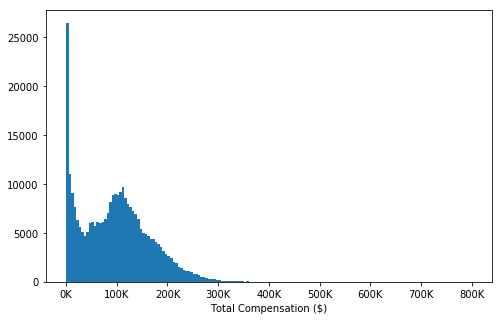

```python
# start with a histogram to see distribution
fig, ax = plt.subplots(figsize=[8, 5])
bins = np.arange(0, 797635.20 + 5000, 5000)
plt.hist(data = sf_data, x = 'total_comp', bins = bins)
plt.xlabel('Total Compensation ($)');
x_format();
```

> According to the chart, the largest group is in the 0 to 5,000 dollar bin. The minimum wage in San Francisco is 15 dollars/hour which comes out to 31,200 dollars annually. Therefore, we want to filter out the part-time workers and only explore full-time workers to reduce skewness. We'll also apply a log-transformation because the skewness was right-skewed.

```python
# filtering out part-time work by total_comp and total_salary
part_time = sf_data[(sf_data.total_comp < 31200) | (sf_data.total_salary < 31200)].index
```

```python
sf_data.drop(index = part_time, inplace = True)
```

```python
# reset the index in order for it to be easier to work with later
sf_data.reset_index(inplace = True, drop = True)
```

```python
# used to find the bins for total_comp log
log_trans(sf_data.total_comp.describe())
```

```
count   5.33
mean    5.10
std     4.73
min     4.50
25%     4.94
50%     5.07
75%     5.20
max     5.90
Name: total_comp, dtype: float64
```

Log-scaled `total_comp` distribution

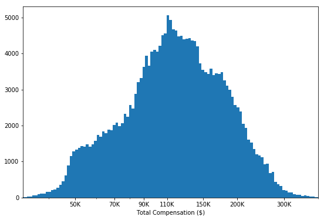

```python
fig, ax = plt.subplots(figsize = [9, 6])
x_ticks = [50000, 70000, 90000, 110000, 150000, 200000, 300000]
bins = 10 ** np.arange(4.50, 5.90 + 0.01, 0.01)
plt.hist(data = sf_data, x = 'total_comp', bins = bins)
plt.xlabel('Total Compensation ($)');
plt.xscale('log');
x_format();
plt.xticks(x_ticks);
#plt.axvline(x = 113287, color = 'r');
plt.xlim(32100, 400000);
```

> Since, `total_comp` had a long-tailed distribution, that was right-skewed, a log-scale transformation was used in order to see a clearer picture. You can see that the it is mostly unimodal with a dip right after the peak which is around 110,000 dollars. This indicates most city employees total compensation lies around 100 thousand dollar which is the median wage in San Francisco according to the [US Census Bureau](https://www.census.gov/library/visualizations/2018/comm/acs-income.html). This indicates a fairly accurate labor market value. Next, we'll explore `total_benefit` and `total_salary`.

```python
sf_data.describe()
```

|  | base_salary | overtime | other_salary | total_salary | retirement | health_dental | other_benefit | total_benefit | total_comp |
| --- | --- | --- | --- | --- | --- | --- | --- | --- | --- |
| count | 215653.00 | 215653.00 | 215653.00 | 215653.00 | 215653.00 | 215653.00 | 215653.00 | 215653.00 | 215653.00 |
| mean | 80129.70 | 6257.21 | 4277.70 | 90664.23 | 16032.53 | 12926.63 | 5956.66 | 36502.11 | 127166.34 |
| std | 35803.29 | 13030.30 | 7528.07 | 42722.66 | 7723.77 | 6848.27 | 3680.16 | 14088.29 | 53912.89 |
| min | 0.00 | 0.00 | 0.00 | 31200.00 | 0.00 | 0.00 | 0.00 | 0.00 | 31505.04 |
| 25% | 54703.00 | 0.00 | 0.00 | 59259.02 | 11046.75 | 8930.10 | 3448.34 | 26725.51 | 88043.61 |
| 50% | 72144.00 | 159.49 | 1440.00 | 80926.06 | 14838.15 | 12424.50 | 5422.50 | 36509.03 | 117894.40 |
| 75% | 101021.21 | 6694.30 | 5569.29 | 114158.50 | 20513.31 | 13342.11 | 7667.77 | 45543.38 | 159191.11 |
| max | 635747.46 | 304546.25 | 342802.63 | 641374.64 | 118963.50 | 36609.50 | 37198.60 | 156260.56 | 797635.20 |

#### Initial Plot `total_salary`

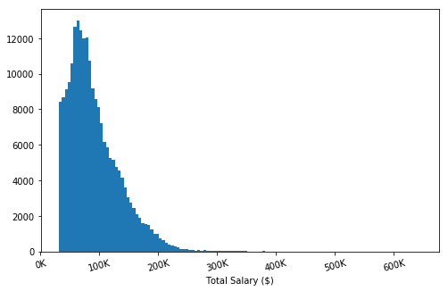

```python
# showing total salary with standard plot
fig, ax = plt.subplots(figsize = [8, 5])
bins = np.arange(31200, 641374.64 + 5000, 5000)
plt.hist(data = sf_data, x = "total_salary", bins = bins);
plt.xlabel('Total Salary ($)');
plt.xticks(rotation = 15);
x_format();
```

> As with the `total_comp` plot, there is a long-tailed right-skewed distribution, so a log transformation is appropriate. We will also investigate extreme outliers as well.

```python
# did a search for total_salary above 400K because that is where the bars above die off.
high_outliers = sf_data[(sf_data.total_salary > 400000)]
high_outliers.sort_values(by = 'total_salary',ascending = False).head()
```

|  | emp_id | year | org_group | job | base_salary | overtime | other_salary | total_salary | retirement | health_dental | other_benefit | total_benefit | total_comp |
| --- | --- | --- | --- | --- | --- | --- | --- | --- | --- | --- | --- | --- | --- |
| 215652 | 8513771 | 2019 | Public Protection | Police Officer 3 | 635747.46 | 2810.25 | 2816.93 | 641374.64 | 118963.50 | 11935.76 | 10983.12 | 156260.56 | 797635.20 |
| 215651 | 8515448 | 2018 | General Administration & Finance | Chief Investment Officer | 537847.86 | 0.00 | 0.00 | 537847.86 | 98677.06 | 29493.84 | 25276.62 | 151681.66 | 689529.52 |
| 215650 | 169 | 2016 | General Administration & Finance | Chief Investment Officer | 527343.14 | 0.00 | 0.00 | 527343.14 | 95045.63 | 13371.04 | 24220.53 | 132637.20 | 659980.34 |
| 215649 | 8515448 | 2019 | General Administration & Finance | Chief Investment Officer | 526818.00 | 0.00 | 0.00 | 526818.00 | 98455.94 | 11935.78 | 24689.99 | 149749.09 | 676567.09 |
| 215648 | 169 | 2015 | General Administration & Finance | Chief Investment Officer | 507831.60 | 0.00 | 0.00 | 507831.60 | 105052.98 | 12424.50 | 23566.16 | 141043.64 | 648875.24 |

```python
# investigating Police Officer 3 since that doesnt match high positions like the others
pol_3 = sf_data[sf_data.job == "Police Officer 3"]
pol_3.total_salary.sort_values(ascending = False).head()
```

```
215652   641374.64
160691   267902.74
193872   246134.52
169812   243129.13
194143   242783.10
Name: total_salary, dtype: float64
```

```python
# looking at the lower end as well
pol_3.total_salary.sort_values(ascending = False).tail()
```

```
892    31902.95
2120   31807.52
315    31772.84
241    31737.52
332    31325.34
Name: total_salary, dtype: float64
```

```python
irr_sal = sf_data[sf_data.index == 215652]
```

```python
irr_sal_index = irr_sal.index
```

```python
# dropped in place
sf_data.drop(index = irr_sal_index, inplace = True)
```

```python
sf_data.reset_index(inplace = True, drop = True)
```

> These job positions and salaries, follow a normal trend of money so we'll keep these. We'll also apply a log transformation to normalize the distribution.

#### `total_salary` log scale

```python
# used to find bins for total_salary log
np.log10(sf_data.total_salary.describe())
```

```
count   5.33
mean    4.96
std     4.63
min     4.49
25%     4.77
50%     4.91
75%     5.06
max     5.73
Name: total_salary, dtype: float64
```

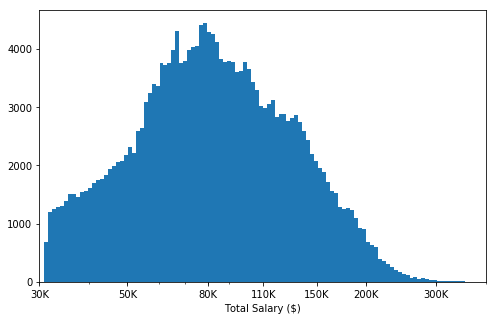

```python
# both distributions are gonna take on a log-scale transformaton
# added x limits in zoom in on distributions
fig, ax = plt.subplots(figsize = [8, 5])
x_ticks = [30000, 50000, 80000, 110000, 150000, 200000, 300000]
bins = 10 ** np.arange(4.49, 5.73 + 0.01, 0.01)
plt.hist(data = sf_data, x = "total_salary", bins = bins);
plt.xlabel('Total Salary ($)');
plt.xscale('log');
x_format();
plt.xticks(x_ticks);
plt.xlim(30000, 400000);
```

> So for `total_salary`, the distribution on a log scale is unimodal and shows that a majority of the total salaries lies just below the 80,000 dollar mark.

#### `total_benefit` initial plot

```python
sf_data.total_benefit.describe()
```

```
count   215652.00
mean     36501.56
std      14085.96
min          0.00
25%      26725.34
50%      36509.00
75%      45543.34
max     151681.66
Name: total_benefit, dtype: float64
```

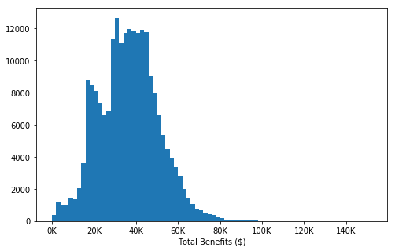

```python
# showing total benefits with standard plot
fig, ax = plt.subplots(figsize = [8, 5])
bins = np.arange(0, 151681.38 + 2000, 2000)
plt.hist(data = sf_data, x = "total_benefit", bins = bins);
plt.xlabel('Total Benefits ($)');
x_format();
```

> This histogram has a long tail that is right skewed, lets investigate some outliers to see if something should be eliminated.

```python
high_outliers = sf_data[sf_data['total_benefit'] > 100000]
high_outliers.sort_values(by = 'total_benefit', ascending = False).head()
```

|  | emp_id | year | org_group | job | base_salary | overtime | other_salary | total_salary | retirement | health_dental | other_benefit | total_benefit | total_comp |
| --- | --- | --- | --- | --- | --- | --- | --- | --- | --- | --- | --- | --- | --- |
| 215651 | 8515448 | 2018 | General Administration & Finance | Chief Investment Officer | 537847.86 | 0.00 | 0.00 | 537847.86 | 98677.06 | 29493.84 | 25276.62 | 151681.66 | 689529.52 |
| 215649 | 8515448 | 2019 | General Administration & Finance | Chief Investment Officer | 526818.00 | 0.00 | 0.00 | 526818.00 | 98455.94 | 11935.78 | 24689.99 | 149749.09 | 676567.09 |
| 215648 | 169 | 2015 | General Administration & Finance | Chief Investment Officer | 507831.60 | 0.00 | 0.00 | 507831.60 | 105052.98 | 12424.50 | 23566.16 | 141043.64 | 648875.24 |
| 215650 | 169 | 2016 | General Administration & Finance | Chief Investment Officer | 527343.14 | 0.00 | 0.00 | 527343.14 | 95045.63 | 13371.04 | 24220.53 | 132637.20 | 659980.34 |
| 215634 | 8555040 | 2018 | General Administration & Finance | Dept Head V | 335775.05 | 0.00 | 0.00 | 335775.05 | 63025.00 | 29507.90 | 30080.40 | 120833.38 | 456608.43 |

> These are part of the same group that have higher end salaries so we'll keep these as well.

```python
low_outliers = sf_data[sf_data['total_benefit'] == 0]
low_outliers.sample(5)
```

|  | emp_id | year | org_group | job | base_salary | overtime | other_salary | total_salary | retirement | health_dental | other_benefit | total_benefit | total_comp |
| --- | --- | --- | --- | --- | --- | --- | --- | --- | --- | --- | --- | --- | --- |
| 93835 | 8532522 | 2019 | Community Health | Manager II | 67234.05 | 0.00 | 0.00 | 67234.05 | 0.00 | 0.00 | 0.00 | 0.00 | 67234.05 |
| 76693 | 8514528 | 2019 | General Administration & Finance | Senior Stationary Engineer | 62279.00 | 5158.79 | 0.00 | 67437.79 | 0.00 | 0.00 | 0.00 | 0.00 | 67437.79 |
| 24567 | 8526576 | 2018 | Public Protection | Senior Stationary Engineer | 41552.10 | 622.60 | 1636.00 | 43810.70 | 0.00 | 0.00 | 0.00 | 0.00 | 43810.70 |
| 146692 | 8552327 | 2018 | Public Protection | Assistant Deputy Chief 2 | 91393.60 | 0.00 | 9305.64 | 100699.24 | 0.00 | 0.00 | 0.00 | 0.00 | 100699.24 |
| 17 | 8532167 | 2018 | Culture & Recreation | EMT/Paramedic/Firefighter | 0.00 | 0.00 | 32280.00 | 32280.00 | 0.00 | 0.00 | 0.00 | 0.00 | 32280.00 |

#### `total_benefit` cube-root transformation

```python
# used to find the bins
np.cbrt(sf_data.describe())
```

|  | base_salary | overtime | other_salary | total_salary | retirement | health_dental | other_benefit | total_benefit | total_comp |
| --- | --- | --- | --- | --- | --- | --- | --- | --- | --- |
| count | 59.97 | 59.97 | 59.97 | 59.97 | 59.97 | 59.97 | 59.97 | 59.97 | 59.97 |
| mean | 43.11 | 18.43 | 16.23 | 44.92 | 25.22 | 23.47 | 18.13 | 33.17 | 50.29 |
| std | 32.95 | 23.53 | 19.60 | 34.95 | 19.76 | 18.99 | 15.44 | 24.15 | 37.77 |
| min | 0.00 | 0.00 | 0.00 | 31.48 | 0.00 | 0.00 | 0.00 | 0.00 | 31.58 |
| 25% | 37.96 | 0.00 | 0.00 | 38.99 | 22.27 | 20.75 | 15.11 | 29.90 | 44.49 |
| 50% | 41.63 | 5.42 | 11.29 | 43.25 | 24.57 | 23.16 | 17.57 | 33.17 | 49.03 |
| 75% | 46.57 | 18.85 | 17.73 | 48.51 | 27.37 | 23.72 | 19.72 | 35.71 | 54.20 |
| max | 81.32 | 67.28 | 69.99 | 81.32 | 47.18 | 33.20 | 33.38 | 53.33 | 88.35 |

```python
# needed to get the cube root of total_benefits isolated
tot_bene = sf_data.total_benefit
cube_tot_bene = np.cbrt(tot_bene)
```

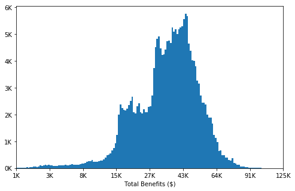

```python
fig, ax = plt.subplots(figsize = [8, 5])
x_ticks = [10, 15, 20, 25, 30, 35, 40, 45, 50]
tick_labels = ['1K', '3K', '8K', '15K', '27K', '43K', '64K', '91K', '125K']
bins = np.arange(0, 53.33 + 0.25, 0.25)
plt.hist(x = cube_tot_bene, bins = bins);
plt.xlabel('Total Benefits ($)');
plt.xticks(x_ticks, tick_labels);
plt.xlim(10, 50);
y_format();
```

> As you can see, `total_benefit` is bi-modal, with a lower peak around 20,000 dollar, and a second higher peak around 43,000 dollars.

#### compare `base_salary`, `overtime` and `other_salary`

```python
sf_data.describe()
```

|  | base_salary | overtime | other_salary | total_salary | retirement | health_dental | other_benefit | total_benefit | total_comp |
| --- | --- | --- | --- | --- | --- | --- | --- | --- | --- |
| count | 215652.00 | 215652.00 | 215652.00 | 215652.00 | 215652.00 | 215652.00 | 215652.00 | 215652.00 | 215652.00 |
| mean | 80127.13 | 6257.23 | 4277.70 | 90661.67 | 16032.05 | 12926.63 | 5956.64 | 36501.56 | 127163.23 |
| std | 35783.38 | 13030.32 | 7528.09 | 42706.30 | 7720.60 | 6848.29 | 3680.15 | 14085.96 | 53893.68 |
| min | 0.00 | 0.00 | 0.00 | 31200.00 | 0.00 | 0.00 | 0.00 | 0.00 | 31505.04 |
| 25% | 54703.00 | 0.00 | 0.00 | 59258.94 | 11046.67 | 8930.10 | 3448.33 | 26725.34 | 88043.55 |
| 50% | 72144.00 | 159.48 | 1440.00 | 80926.05 | 14838.12 | 12424.50 | 5422.42 | 36509.00 | 117893.88 |
| 75% | 101019.56 | 6694.48 | 5569.32 | 114156.71 | 20512.94 | 13342.11 | 7667.77 | 45543.34 | 159190.97 |
| max | 537847.86 | 304546.25 | 342802.63 | 537847.86 | 105052.98 | 36609.50 | 37198.60 | 151681.66 | 689529.52 |

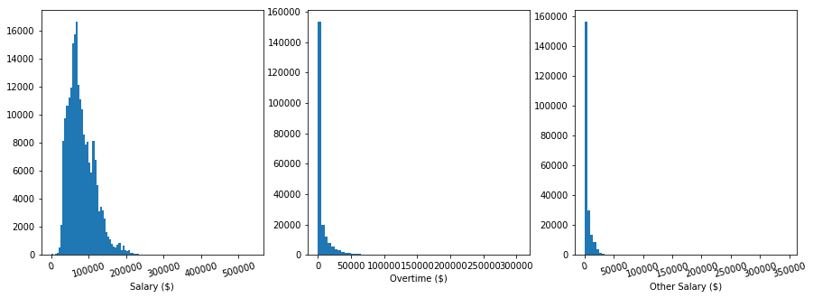

```python
plt.figure(figsize=[15,5])

# base_salary
bins = np.arange(0, 537847.86 + 5000, 5000)
plt.subplot(1, 3, 1)
plt.hist(data = sf_data, x = "base_salary", bins = bins);
plt.xlabel('Salary ($)');
plt.xticks(rotation = 15)

# overtime
bins2 = np.arange(0, 304546.25 + 5000, 5000)
plt.subplot(1, 3, 2)
plt.hist(data = sf_data, x = "overtime", bins = bins2);
plt.xlabel('Overtime ($)');

# other_salary
bins3 = np.arange(0, 342802.63 + 5000, 5000)
plt.subplot(1, 3, 3)
plt.hist(data = sf_data, x = "other_salary", bins = bins3);
plt.xlabel('Other Salary ($)');
plt.xticks(rotation = 15);
```

> Let's take a look at high and low outliers.

```python
high_outliers = ((sf_data['base_salary'] > 250000) | (sf_data['overtime'] > 60000) | (sf_data['other_salary'] > 40000))
```

```python
sf_data[high_outliers].sort_values(by = ['base_salary'], ascending = False).head(10)
```

|  | emp_id | year | org_group | job | base_salary | overtime | other_salary | total_salary | retirement | health_dental | other_benefit | total_benefit | total_comp |
| --- | --- | --- | --- | --- | --- | --- | --- | --- | --- | --- | --- | --- | --- |
| 215651 | 8515448 | 2018 | General Administration & Finance | Chief Investment Officer | 537847.86 | 0.00 | 0.00 | 537847.86 | 98677.06 | 29493.84 | 25276.62 | 151681.66 | 689529.52 |
| 215650 | 169 | 2016 | General Administration & Finance | Chief Investment Officer | 527343.14 | 0.00 | 0.00 | 527343.14 | 95045.63 | 13371.04 | 24220.53 | 132637.20 | 659980.34 |
| 215649 | 8515448 | 2019 | General Administration & Finance | Chief Investment Officer | 526818.00 | 0.00 | 0.00 | 526818.00 | 98455.94 | 11935.78 | 24689.99 | 149749.09 | 676567.09 |
| 215648 | 169 | 2015 | General Administration & Finance | Chief Investment Officer | 507831.60 | 0.00 | 0.00 | 507831.60 | 105052.98 | 12424.50 | 23566.16 | 141043.64 | 648875.24 |
| 215647 | 8585792 | 2018 | General Administration & Finance | Managing Director | 449807.87 | 0.00 | 0.00 | 449807.87 | 82524.71 | 0.00 | 36632.28 | 119156.99 | 568964.86 |
| 215646 | 8596212 | 2018 | General Administration & Finance | Managing Director | 449807.86 | 0.00 | 0.00 | 449807.86 | 82524.71 | 0.00 | 23816.10 | 106340.81 | 556148.67 |
| 215645 | 8585792 | 2019 | General Administration & Finance | Managing Director | 440582.00 | 0.00 | 0.00 | 440582.00 | 82339.39 | 0.00 | 34604.17 | 116943.56 | 557525.56 |
| 215644 | 8532658 | 2018 | Community Health | Physician Administrator, DPH | 409589.88 | 0.00 | 0.00 | 409589.88 | 76879.97 | 0.00 | 31233.81 | 108113.78 | 517703.66 |
| 215643 | 8551077 | 2018 | General Administration & Finance | Managing Director | 403387.92 | 0.00 | 304.29 | 403692.21 | 74045.44 | 0.00 | 34204.03 | 108249.47 | 511941.68 |
| 215642 | 49809 | 2016 | General Administration & Finance | Managing Director | 394941.72 | 0.00 | 0.00 | 394941.72 | 71133.15 | 12342.50 | 20175.73 | 103651.38 | 498593.10 |

```python
sf_data[high_outliers].sort_values(by = 'overtime', ascending= False).head()
```

|  | emp_id | year | org_group | job | base_salary | overtime | other_salary | total_salary | retirement | health_dental | other_benefit | total_benefit | total_comp |
| --- | --- | --- | --- | --- | --- | --- | --- | --- | --- | --- | --- | --- | --- |
| 166124 | 8555596 | 2018 | Public Protection | Deputy Sheriff | 104175.06 | 304546.25 | 17529.39 | 426250.70 | 34632.44 | 28366.56 | 7283.79 | 69644.83 | 495895.53 |
| 172201 | 8555574 | 2019 | Public Protection | Senior Deputy Sheriff | 109304.11 | 280237.55 | 22908.38 | 412450.04 | 44358.09 | 11935.78 | 7009.95 | 77971.20 | 490421.24 |
| 163855 | 54876 | 2016 | Public Protection | Deputy Sheriff | 102547.00 | 261717.31 | 24200.70 | 388465.01 | 32729.60 | 13371.04 | 6650.10 | 52750.74 | 441215.75 |
| 165481 | 8586470 | 2018 | Public Protection | Deputy Sheriff | 103758.33 | 258365.81 | 24855.08 | 386979.22 | 35921.87 | 29493.86 | 6550.90 | 70089.77 | 457068.99 |
| 149737 | 8555596 | 2019 | Public Protection | Deputy Sheriff | 93428.11 | 258346.80 | 15353.35 | 367128.26 | 36591.64 | 11935.76 | 6257.15 | 68182.71 | 435310.97 |

```python
sf_data[high_outliers].sort_values(by = 'other_salary', ascending= False).head()
```

|  | emp_id | year | org_group | job | base_salary | overtime | other_salary | total_salary | retirement | health_dental | other_benefit | total_benefit | total_comp |
| --- | --- | --- | --- | --- | --- | --- | --- | --- | --- | --- | --- | --- | --- |
| 195480 | 49255 | 2014 | Public Protection | Deputy Chief 3 | 129150.01 | 0.00 | 342802.63 | 471952.64 | 27477.98 | 6276.42 | 4867.41 | 38621.81 | 510574.45 |
| 480 | 9368 | 2016 | Public Protection | Asst Chf Of Dept (Fire Dept) | 21740.70 | 0.00 | 229344.52 | 251085.22 | 4220.95 | 1697.10 | 58.91 | 5976.96 | 257062.18 |
| 192159 | 31480 | 2013 | Public Protection | Assistant Deputy Chief 2 | 124054.00 | 0.00 | 202322.37 | 326376.37 | 24166.94 | 6698.35 | 321.53 | 31186.82 | 357563.19 |
| 139934 | 62 | 2014 | Public Protection | Captain 3 | 87324.00 | 0.00 | 199112.35 | 286436.35 | 18881.89 | 5724.09 | 147.15 | 24753.13 | 311189.48 |
| 28 | 28328 | 2017 | Public Protection | Chief Of Police | 0.00 | 0.00 | 191685.15 | 191685.15 | 0.00 | 0.00 | 0.00 | 0.00 | 191685.15 |

```python
base_outliers = sf_data[sf_data.base_salary > 250000]
base_outliers.sort_values(ascending = False, by = ['job','base_salary']).head()
```

|  | emp_id | year | org_group | job | base_salary | overtime | other_salary | total_salary | retirement | health_dental | other_benefit | total_benefit | total_comp |
| --- | --- | --- | --- | --- | --- | --- | --- | --- | --- | --- | --- | --- | --- |
| 215628 | 23204 | 2017 | Public Works, Transportation & Commerce | Transit Operator | 323901.54 | 523.33 | 471.18 | 324896.05 | 86354.92 | 5515.75 | 13460.71 | 105331.38 | 430227.43 |
| 215497 | 8602049 | 2018 | Community Health | Supervising Physician Spec | 264777.16 | 0.00 | 4185.00 | 268962.16 | 49698.61 | 29493.80 | 12872.11 | 90174.66 | 359136.82 |
| 215494 | 8848 | 2016 | Community Health | Supervising Physician Spec | 264010.52 | 0.00 | 4140.00 | 268150.52 | 47390.18 | 13371.03 | 12363.93 | 73125.14 | 341275.66 |
| 215495 | 43903 | 2016 | Community Health | Supervising Physician Spec | 264010.52 | 0.00 | 6105.00 | 270115.52 | 47605.38 | 13371.04 | 12369.49 | 73345.91 | 343461.43 |
| 215493 | 13660 | 2016 | Community Health | Supervising Physician Spec | 264010.51 | 0.00 | 3015.00 | 267025.51 | 47390.17 | 13371.03 | 12379.81 | 73141.01 | 340166.52 |

```python
sf_data[sf_data.job == "Transit Operator"].base_salary.sort_values(ascending = False).head()
```

```
215628   323901.54
163185   102048.96
129798    81984.00
129095    81698.05
127106    80775.63
Name: base_salary, dtype: float64
```

```python
sf_data[sf_data.job == "Transit Operator"].base_salary.sort_values(ascending = False).tail()
```

```
298   18907.08
254   17589.58
198   15133.43
190   14698.67
96     6056.40
Name: base_salary, dtype: float64
```

```python
irr_base_sal = sf_data[(sf_data.index == 215628)]
```

> The salary range for a Transit Operator is between 6,000 and 102,000 dollars. Therefore, the operator with a salary over 300,000 is probably a typo. It'll be thrown out.

```python
irr_base_sal_index = irr_base_sal.index
```

```python
# dropped these in place
sf_data.drop(index = irr_base_sal_index, inplace = True)
```

```python
sf_data.reset_index(inplace = True, drop = True)
```

```python
sf_data.describe()
```

|  | base_salary | overtime | other_salary | total_salary | retirement | health_dental | other_benefit | total_benefit | total_comp |
| --- | --- | --- | --- | --- | --- | --- | --- | --- | --- |
| count | 215651.00 | 215651.00 | 215651.00 | 215651.00 | 215651.00 | 215651.00 | 215651.00 | 215651.00 | 215651.00 |
| mean | 80126.00 | 6257.25 | 4277.72 | 90660.59 | 16031.72 | 12926.67 | 5956.60 | 36501.24 | 127161.83 |
| std | 35779.61 | 13030.35 | 7528.10 | 42703.42 | 7719.14 | 6848.28 | 3680.12 | 14085.21 | 53889.86 |
| min | 0.00 | 0.00 | 0.00 | 31200.00 | 0.00 | 0.00 | 0.00 | 0.00 | 31505.04 |
| 25% | 54703.00 | 0.00 | 0.00 | 59258.86 | 11046.58 | 8930.10 | 3448.32 | 26725.17 | 88043.49 |
| 50% | 72144.00 | 159.47 | 1440.00 | 80926.05 | 14838.10 | 12424.50 | 5422.34 | 36508.97 | 117893.37 |
| 75% | 101018.99 | 6694.66 | 5569.34 | 114154.59 | 20512.81 | 13342.11 | 7667.75 | 45542.95 | 159190.17 |
| max | 537847.86 | 304546.25 | 342802.63 | 537847.86 | 105052.98 | 36609.50 | 37198.60 | 151681.66 | 689529.52 |

```python
low_outliers = (sf_data['base_salary'] < 20000)
sf_data[low_outliers].sample(5)
```

|  | emp_id | year | org_group | job | base_salary | overtime | other_salary | total_salary | retirement | health_dental | other_benefit | total_benefit | total_comp |
| --- | --- | --- | --- | --- | --- | --- | --- | --- | --- | --- | --- | --- | --- |
| 6 | 8584522 | 2019 | Public Protection | Firefighter | 0.00 | 0.00 | 62277.52 | 62277.52 | 0.00 | 0.00 | 903.02 | 903.02 | 63180.54 |
| 49 | 23637 | 2016 | Public Protection | Deputy Sheriff | 0.00 | 0.00 | 31406.88 | 31406.88 | 0.00 | 98.16 | 0.00 | 98.16 | 31505.04 |
| 122 | 8047 | 2017 | Public Works, Transportation & Commerce | Electrl Trnst Mech, Asst Sprv | 8813.20 | 4885.76 | 26471.17 | 40170.13 | 1743.22 | 1080.99 | 3119.29 | 5943.50 | 46113.63 |
| 211 | 33708 | 2016 | Public Protection | Police Officer | 15800.00 | 13590.47 | 2776.17 | 32166.64 | 2963.84 | 2057.09 | 540.48 | 5561.41 | 37728.05 |
| 91 | 52674 | 2015 | Public Protection | Inspector 3 | 5307.00 | 0.00 | 99569.13 | 104876.13 | 1213.98 | 477.86 | 14.19 | 1706.03 | 106582.16 |

> There are some entries where `salary` and `other_salary` could've been switched because according to the definitions. `Salary` is the base pay and the `other_salary` is premium, incentive pay, or irregular payments made to the individual. Therefore, another query will be performed to eliminate the oddly paid individuals because we cannot investigate the nature of their pay and is affecting the data.

```python
irregular_incomes = sf_data[((sf_data['base_salary']) <= (sf_data['other_salary']))
                            & ((sf_data['base_salary'] == 0))]
irregular_incomes.head()
```

|  | emp_id | year | org_group | job | base_salary | overtime | other_salary | total_salary | retirement | health_dental | other_benefit | total_benefit | total_comp |
| --- | --- | --- | --- | --- | --- | --- | --- | --- | --- | --- | --- | --- | --- |
| 0 | 7633 | 2013 | General Administration & Finance | Manager III | 0.00 | 0.00 | 38689.48 | 38689.48 | 0.00 | 0.00 | 2959.75 | 2959.75 | 41649.23 |
| 1 | 23904 | 2016 | Community Health | Marriage, Family & Child Cnslr | 0.00 | 0.00 | 56250.00 | 56250.00 | 0.00 | 0.00 | 4455.01 | 4455.01 | 60705.01 |
| 2 | 40825 | 2013 | Public Protection | Police Officer | 0.00 | 0.00 | 48336.08 | 48336.08 | 0.00 | 0.00 | 705.77 | 705.77 | 49041.85 |
| 3 | 16408 | 2016 | Public Protection | Lieutenant, Fire Suppression | 0.00 | 0.00 | 45783.12 | 45783.12 | 0.00 | 0.00 | 0.00 | 0.00 | 45783.12 |
| 4 | 34415 | 2017 | Public Protection | Incident Support Specialist | 0.00 | 0.00 | 36674.92 | 36674.92 | 0.00 | 216.70 | 546.99 | 763.69 | 37438.61 |

```python
index_irr_income = irregular_incomes.index
```

```python
# dropped these in place
sf_data.drop(index = index_irr_income, inplace = True)
```

```python
sf_data.reset_index(inplace = True, drop = True)
```

```python
sf_data.describe()
```

|  | base_salary | overtime | other_salary | total_salary | retirement | health_dental | other_benefit | total_benefit | total_comp |
| --- | --- | --- | --- | --- | --- | --- | --- | --- | --- |
| count | 215600.00 | 215600.00 | 215600.00 | 215600.00 | 215600.00 | 215600.00 | 215600.00 | 215600.00 | 215600.00 |
| mean | 80144.95 | 6258.73 | 4262.83 | 90666.13 | 16035.52 | 12929.72 | 5957.67 | 36509.53 | 127175.66 |
| std | 35762.61 | 13031.53 | 7444.76 | 42703.15 | 7716.11 | 6846.22 | 3679.75 | 14076.53 | 53885.67 |
| min | 302.14 | 0.00 | 0.00 | 31200.00 | 0.00 | 0.00 | 0.00 | 0.00 | 31694.91 |
| 25% | 54703.00 | 0.00 | 0.00 | 59269.60 | 11049.71 | 8937.62 | 3449.86 | 26735.65 | 88057.08 |
| 50% | 72144.00 | 160.72 | 1440.00 | 80932.99 | 14840.28 | 12424.50 | 5422.99 | 36512.52 | 117906.52 |
| 75% | 101039.35 | 6698.11 | 5564.54 | 114165.00 | 20514.87 | 13342.78 | 7668.64 | 45545.23 | 159200.41 |
| max | 537847.86 | 304546.25 | 342802.63 | 537847.86 | 105052.98 | 36609.50 | 37198.60 | 151681.66 | 689529.52 |

```python
# log bins for base_salary
np.log10(sf_data.base_salary.describe())
```

```
count   5.33
mean    4.90
std     4.55
min     2.48
25%     4.74
50%     4.86
75%     5.00
max     5.73
Name: base_salary, dtype: float64
```

```python
np.cbrt(sf_data.describe())
```

|  | base_salary | overtime | other_salary | total_salary | retirement | health_dental | other_benefit | total_benefit | total_comp |
| --- | --- | --- | --- | --- | --- | --- | --- | --- | --- |
| count | 59.96 | 59.96 | 59.96 | 59.96 | 59.96 | 59.96 | 59.96 | 59.96 | 59.96 |
| mean | 43.11 | 18.43 | 16.21 | 44.92 | 25.22 | 23.47 | 18.13 | 33.17 | 50.29 |
| std | 32.95 | 23.53 | 19.53 | 34.95 | 19.76 | 18.99 | 15.44 | 24.15 | 37.77 |
| min | 6.71 | 0.00 | 0.00 | 31.48 | 0.00 | 0.00 | 0.00 | 0.00 | 31.65 |
| 25% | 37.96 | 0.00 | 0.00 | 38.99 | 22.27 | 20.75 | 15.11 | 29.90 | 44.49 |
| 50% | 41.63 | 5.44 | 11.29 | 43.26 | 24.57 | 23.16 | 17.57 | 33.18 | 49.04 |
| 75% | 46.58 | 18.85 | 17.72 | 48.51 | 27.38 | 23.72 | 19.72 | 35.71 | 54.20 |
| max | 81.32 | 67.28 | 69.99 | 81.32 | 47.18 | 33.20 | 33.38 | 53.33 | 88.35 |

```python
# setting data for overtime and other_salary cube root
cube_ot = np.cbrt(sf_data['overtime'])
cube_other_salary = np.cbrt(sf_data['other_salary'])
```

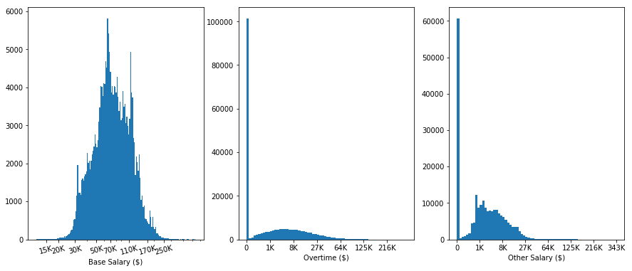

```python
plt.figure(figsize=[15,6])

# base_salary log transformation
x_ticks = [15000, 20000, 30000, 50000, 70000, 110000, 170000, 250000]
bins = 10 ** np.arange(4.07, 5.73 + 0.01, 0.01)
plt.subplot(1, 3, 1)
plt.hist(data = sf_data, x = "base_salary", bins = bins);
plt.xlabel('Base Salary ($)');
plt.xscale('log')
plt.xticks(rotation = 15)
plt.xticks(x_ticks, ['15K', '20K', '30K', '50K', '70K', '110K', '170K', '250K'])


# overtime cuberoot transformation
x_ticks = [0, 10, 20, 30, 40, 50, 60]
labels = [0, '1K', '8K', '27K', '64K', '125K', '216K']
bins2 = np.arange(0, 67.28 + 1, 1)
plt.subplot(1, 3, 2)
plt.hist(x = cube_ot, bins = bins2);
plt.xlabel('Overtime ($)');
plt.xticks(x_ticks, labels);



# other_salary cuberoot transformation
x_ticks = [0, 10, 20, 30, 40, 50, 60, 70]
labels = [0, '1K', '8K', '27K', '64K', '125K', '216K', '343K']
bins3 = np.arange(0, 69.99 + 1, 1)
plt.subplot(1, 3, 3)
plt.hist(x = cube_other_salary, bins = bins3);
plt.xlabel('Other Salary ($)');
plt.xticks(x_ticks, labels);
```

> The `base_salary` distribution is unimodal and peaks around 60,000 dollars and follows a normal distribution.

#### `retirement`, `health_dental`, and `other_benefits`

```python
sf_data[{'retirement', 'health_dental', 'other_benefit' }].describe()
```

|  | retirement | other_benefit | health_dental |
| --- | --- | --- | --- |
| count | 215600.00 | 215600.00 | 215600.00 |
| mean | 16035.52 | 5957.67 | 12929.72 |
| std | 7716.11 | 3679.75 | 6846.22 |
| min | 0.00 | 0.00 | 0.00 |
| 25% | 11049.71 | 3449.86 | 8937.62 |
| 50% | 14840.28 | 5422.99 | 12424.50 |
| 75% | 20514.87 | 7668.64 | 13342.78 |
| max | 105052.98 | 37198.60 | 36609.50 |

#### Standard Histogram for `retirement`, `health_dental`, and `other_benefit`

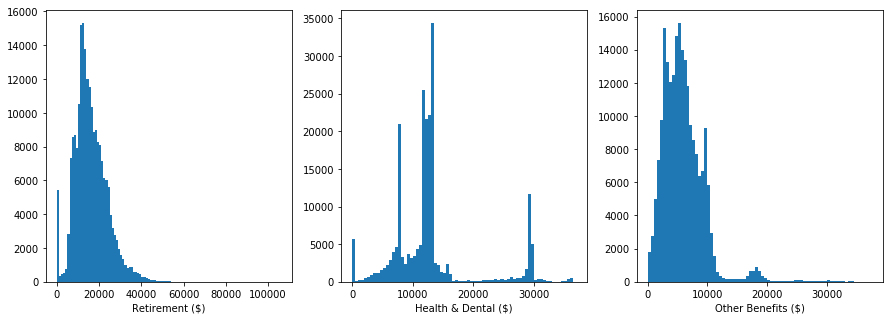

```python
plt.figure(figsize=[15,5])

# retirement
bins = np.arange(0, 105052.98 + 1000, 1000)
plt.subplot(1, 3, 1)
plt.hist(data = sf_data, x = "retirement", bins = bins);
plt.xlabel('Retirement ($)');


# health_dental
bins2 = np.arange(0, 36609.50 + 500, 500)
plt.subplot(1, 3, 2)
plt.hist(data = sf_data, x = "health_dental", bins = bins2);
plt.xlabel('Health & Dental ($)');


# other_benefit
bins3 = np.arange(0, 37198.60 + 500, 500)
plt.subplot(1, 3, 3)
plt.hist(data = sf_data, x = "other_benefit", bins = bins3);
plt.xlabel('Other Benefits ($)');
x_format();
plt.xticks(rotation = 0);
```

> The `retirement` and `other_benefit` charts look like they are right-skewed so a cubic root transformation would be helpful. There is also a spike in the `retirement` chart at 0 dollars which should be investigated further.

> The `health_dental` chart is multimodal distribution with the first spike around 8,000 dollars and the second at around 13,000.

```python
sf_data[sf_data['retirement'] == 0].sample(5)
```

|  | emp_id | year | org_group | job | base_salary | overtime | other_salary | total_salary | retirement | health_dental | other_benefit | total_benefit | total_comp |
| --- | --- | --- | --- | --- | --- | --- | --- | --- | --- | --- | --- | --- | --- |
| 46210 | 8508210 | 2018 | Community Health | Special Nurse | 51625.20 | 0.00 | 8408.65 | 60033.85 | 0.00 | 0.00 | 2954.59 | 2954.59 | 62988.44 |
| 86984 | 8507477 | 2018 | Community Health | Special Nurse | 65428.34 | 5734.04 | 2163.05 | 73325.43 | 0.00 | 0.00 | 1277.12 | 1277.12 | 74602.55 |
| 12388 | 8540966 | 2018 | Community Health | Special Nurse | 35575.16 | 1091.26 | 543.31 | 37209.73 | 0.00 | 0.00 | 2888.07 | 2888.07 | 40097.80 |
| 12973 | 8495882 | 2018 | Community Health | Special Nurse | 35862.67 | 0.00 | 1075.07 | 36937.74 | 0.00 | 0.00 | 2154.44 | 2154.44 | 39092.18 |
| 13922 | 55624 | 2015 | Human Welfare & Neighborhood Development | Clinical Psychologist | 36358.63 | 0.00 | 80.00 | 36438.63 | 0.00 | 4136.52 | 2895.48 | 7032.00 | 43470.63 |

```python
# bins for retirement and other_benefit cube root
np.cbrt(sf_data[{'retirement', 'other_benefit'}].describe())
```

|  | retirement | other_benefit |
| --- | --- | --- |
| count | 59.96 | 59.96 |
| mean | 25.22 | 18.13 |
| std | 19.76 | 15.44 |
| min | 0.00 | 0.00 |
| 25% | 22.27 | 15.11 |
| 50% | 24.57 | 17.57 |
| 75% | 27.38 | 19.72 |
| max | 47.18 | 33.38 |

```python
# setting data cube root transformation for both variables
cube_retire = np.cbrt(sf_data['retirement'])
cube_benefit = np.cbrt(sf_data['other_benefit'])
```

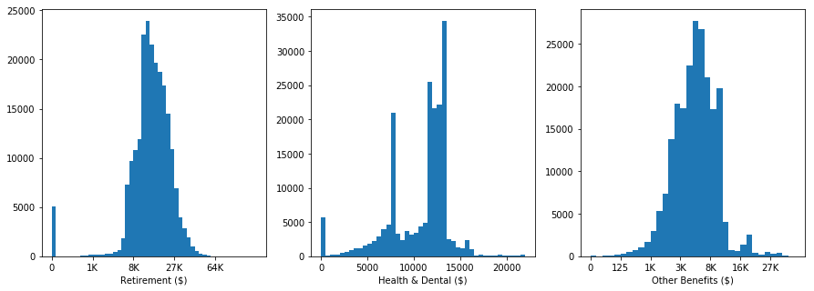

```python
# applied transformations
plt.figure(figsize=[15,5])

# retirement
x_ticks = [0, 10, 20, 30, 40]
labels = [0, '1K', '8K', '27K', '64K']
bins = np.arange(0, 49.18 + 1, 1)
plt.subplot(1, 3, 1)
plt.hist(x = cube_retire, bins = bins);
plt.xlabel('Retirement ($)');
plt.xticks(x_ticks, labels);


# health_dental
bins2 = np.arange(0, 21715.08 + 500, 500)
plt.subplot(1, 3, 2)
plt.hist(data = sf_data, x = "health_dental", bins = bins2);
plt.xlabel('Health & Dental ($)');


# other_benefit
x_ticks = [0, 5, 10, 15, 20, 25, 30]
labels = [0, '125', '1K', '3K', '8K', '16K', '27K']
bins3 = np.arange(0, 33.38 + 1, 1)
plt.subplot(1, 3, 3)
plt.hist(x = cube_benefit, bins = bins3);
plt.xlabel('Other Benefits ($)');
plt.xticks(x_ticks, labels);
```

> For the `retirement` variable, its bimodal with a significant peak around the 15,000 dollar mark and one at the 0 dollar mark. The retirement accounts are a portion of contribution by the city of San Francisco, so its a percentage of how much someone contributes based on their salary. The spike at 0 dollar indicates those people who have chosen not to make contributions to their retirement or the people who have chosen an alternative plan that the city does not contribute to.

> The `health_dental` has a bimodal distribution with one major peak at around 7,500 dollars and another at 12,500 dollars. There are most likely two spikes because most employers have insurance coverage options on a tier basis. This would indicate 2 different health/dental plan tiers and is probably distributed based on a percentage of income as well. There is also a small spike at 0 which would indicate those employees opting to not participate in coverage or possibly not offered based on other criteria.

> The `other_benefit` has a unimodal distribution that is normal and according to the data dictionary, this is the mandatory amount contributed such as Social Security, FICA, Medicare, unemployment insurance, etc. This is solely based on the percentage of income, therefore that is why it is varied with a peak most likely in connection with the median income of the total data set. Also, the peak is around 5,000 dollars.

#### Exploring non-numeric variables

##### `org_group`

> An Organizational Group is a group of departments, such as the Public Protection Group comprises departments such as: Police, Fire, Adult Probation, District Attorney, and Sheriff.

```python
sf_data.org_group.value_counts()
```

```
Public Works, Transportation & Commerce     73241
Public Protection                           48634
Community Health                            48088
General Administration & Finance            18914
Human Welfare & Neighborhood Development    15737
Culture & Recreation                        10986
Name: org_group, dtype: int64
```

```python
# made these category names easier to work with
org_series = sf_data.org_group
org_series.replace({'Public Works, Transportation & Commerce': 'Pub Wrks, Tran & Comm.',
                    'Community Health': 'Comm. Health',
                    'Public Protection': 'Pub. Protect',
                    'Human Welfare & Neighborhood Development': 'Hmn Wlfr & Nbrhd Dev.',
                    'General Administration & Finance': 'Gen Admin & Fin.',
                    'Culture & Recreation': 'Culture & Rec.'}, inplace=True)
```

```python
sf_data.org_group.value_counts()
```

```
Pub Wrks, Tran & Comm.    73241
Pub. Protect              48634
Comm. Health              48088
Gen Admin & Fin.          18914
Hmn Wlfr & Nbrhd Dev.     15737
Culture & Rec.            10986
Name: org_group, dtype: int64
```

```python
group_cats = ['Pub Wrks, Tran & Comm.', 'Pub. Protect', 'Comm. Health',
              'Gen Admin & Fin.', 'Hmn Wlfr & Nbrhd Dev.', 'Culture & Rec.']
categories = pd.api.types.CategoricalDtype(ordered = True, categories = group_cats)
sf_data['org_group'] = sf_data['org_group'].astype(categories)
```

```python
group_cats = sf_data.org_group.value_counts()
labels = group_cats.index
```

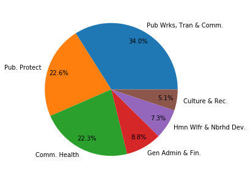

```python
# Pie Chart shows distributions of Proportions of Employees in each Organizational Group
plt.figure(figsize= [6,5])
plt.pie(group_cats, autopct='%1.1f%%', labels = labels, pctdistance = 0.83);
```

> The pie chart shows the largest employed group is Public Works, Transportation and Community, while the lowest is Culture and Recreation.

##### `job`

```python
# EXPLORING JOB
top_five_job = sf_data.job.value_counts().sort_values(ascending = False).head(5).index
top_five_job
```

```
Index(['Transit Operator', 'Registered Nurse', 'Firefighter',
       'Police Officer 3', 'Custodian'],
      dtype='object')
```

```python
# getting top jobs
top_five_by_job = (sf_data[sf_data.job.isin(top_five_job)].job.value_counts())
top_five_by_job
```

```
Transit Operator    14830
Registered Nurse     8759
Firefighter          5710
Police Officer 3     5067
Custodian            4574
Name: job, dtype: int64
```

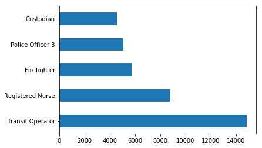

```python
# countplot top five jobs
top_five_by_job.plot(kind='barh');
```

> There are 1,097 job descriptions, which is too high to view on a categorical basis, so this variable might be thrown out. The top 5 however were: Transit Operator, Registered Nurse, Firefighter, Police Officer 3, and Custodian. This information might be useful when exploring with other variables.

##### `year`

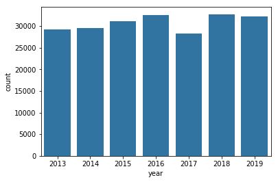

```python
# exploring year
base_color = sb.color_palette()[0]
sb.countplot(data= sf_data, x = 'year', color = base_color);
```

> This countplot shows that the amount of employees each year is relatively the same.

### Discuss the distribution(s) of your variable(s) of interest. Were there any unusual points? Did you need to perform any transformations?

> The variable `total_comp` had a long tail and right-skewed distribution. The highest peak was at the 5,000 dollars and below. Since, the minimum wage in San Francisco is 15 dollars/hour, which is 31,200 dollars annually, those entries were filtered out to eliminate part-time workers. Also, do to the extreme range of values, a log transformation was applied to the variable.

### Of the features you investigated, were there any unusual distributions? Did you perform any operations on the data to tidy, adjust, or change the form of the data? If so, why did you do this?

> There were several extreme outliers for the other variables that did not match the descriptions of job titles. Therefore, those entries were removed as well. Also, compensation where there were no base salaries, and only lump sum payments were thrown out as well.

### Feature Engineering

```python
sf_data_trans = sf_data.copy()
```

```python
# log columns
sf_data_trans['log_salary'] = sf_data_trans['base_salary'].apply(log_trans)
sf_data_trans['log_total_comp'] = sf_data_trans['total_comp'].apply(log_trans)
sf_data_trans['log_total_salary'] = sf_data_trans['total_salary'].apply(log_trans)
# cuberoot columns
sf_data_trans['cr_overtime'] = sf_data_trans['overtime'].apply(cr_trans)
sf_data_trans['cr_other_salary'] = sf_data_trans['other_salary'].apply(cr_trans)
sf_data_trans['cr_retirement'] = sf_data_trans['retirement'].apply(cr_trans)
sf_data_trans['cr_other_benefit'] = sf_data_trans['other_benefit'].apply(cr_trans)
sf_data_trans['cr_total_benefit'] = sf_data_trans['total_benefit'].apply(cr_trans)
```

```python
# saving cleaned copy for explanatory analysis
sf_data_trans.to_csv(path_or_buf='master_sf_salary.csv', index = False)
```

```python
# take a sample of the dataset so the scatterplot will process quicker
np.random.seed(2018)
sample = np.random.choice(sf_data_trans.shape[0], 2000, replace = False)
sf_subset = sf_data_trans.iloc[sample]
```

## Bivariate Exploration

> In this section, investigate relationships between pairs of variables in your data. Make sure the variables that you cover here have been introduced in some fashion in the previous section (univariate exploration).

```python
# set continuous variables
variables = ['base_salary', 'overtime', 'other_salary', 'total_salary', 'retirement',
       'health_dental', 'other_benefit', 'total_benefit', 'total_comp']
vars_trans = ['log_salary', 'cr_overtime', 'cr_other_salary', 'log_total_salary',
              'cr_retirement', 'health_dental', 'cr_other_benefit', 'cr_total_benefit',
              'log_total_comp']
vars_semi_trans = ['base_salary', 'cr_overtime', 'cr_other_salary', 'total_salary', 'retirement',
       'health_dental', 'other_benefit', 'total_benefit', 'total_comp']
```

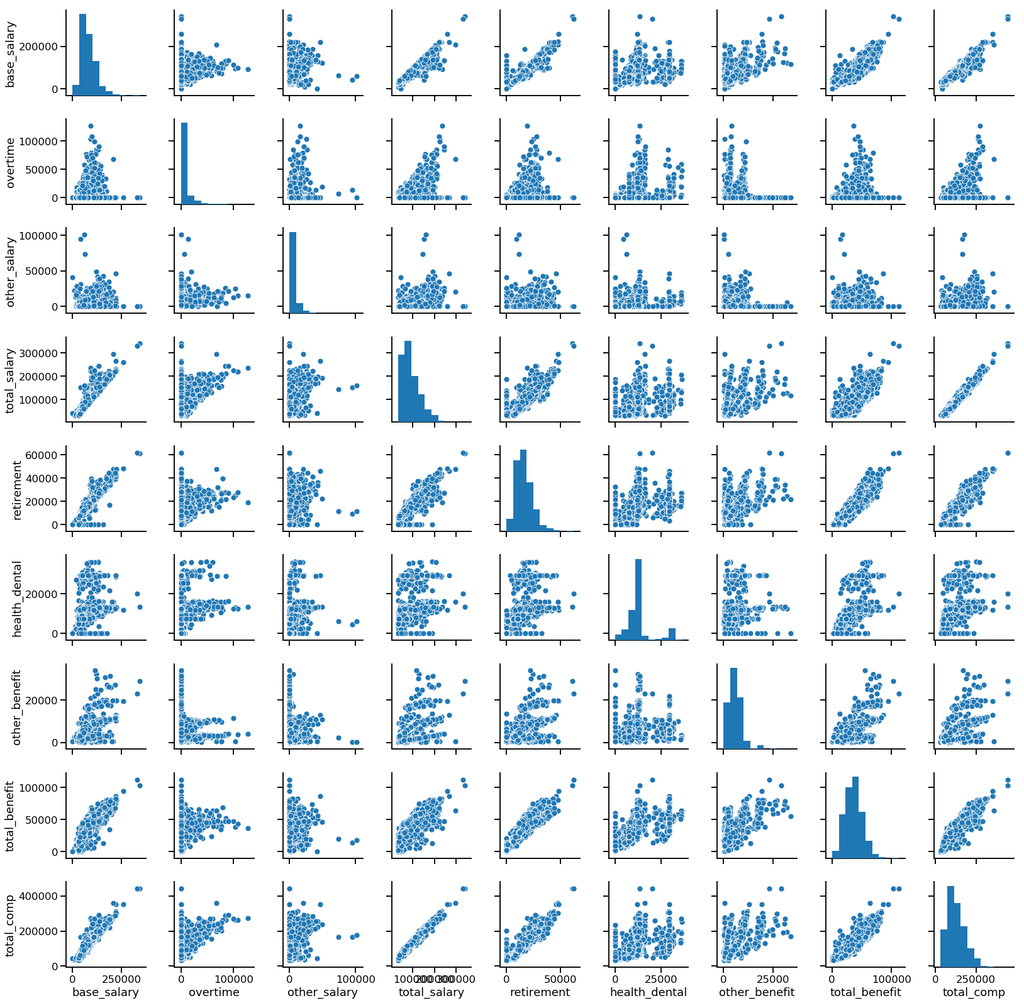

```python
#scatter plot
sb.set_context('talk')
sb.pairplot(data = sf_subset, vars = variables);
```

> Due to the number of continuous variables, a heatmap might be able to show correlation in a more condensed version.

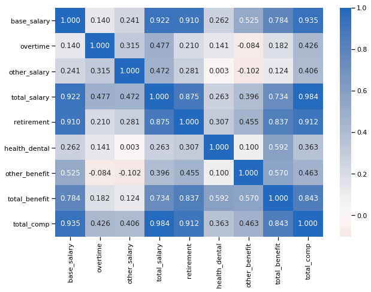

```python
# heat map of continuous variables UNTRANSFORMED
sb.set_context('notebook')
plt.figure(figsize = [10,7])
sb.heatmap(sf_data[variables].corr(), annot = True, fmt = '.3f',
          cmap = 'vlag_r', center = 0);
```

> Areas of Interest
> - `salary` v `overtime`
> - `overtime` v `other_benefit`
> - `other_salary` v `other_benefit`
> - `retirement` v `total_comp`
> - `base_salary` v `total_comp`

##### `overtime` v `other_benefit`

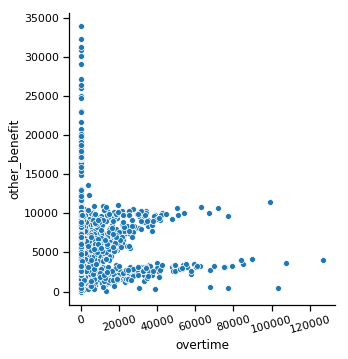

```python
# relplot `overtime` vs `other_benefit`
sb.relplot(data = sf_subset, x = 'overtime', y = 'other_benefit');
plt.xticks(rotation = 15);
```

```python
sf_subset[{'other_benefit', 'overtime', 'cr_other_benefit',
             'cr_overtime'}].corr()
```

|  | cr_overtime | overtime | other_benefit | cr_other_benefit |
| --- | --- | --- | --- | --- |
| cr_overtime | 1.00 | 0.83 | -0.21 | -0.22 |
| overtime | 0.83 | 1.00 | -0.11 | -0.13 |
| other_benefit | -0.21 | -0.11 | 1.00 | 0.94 |
| cr_other_benefit | -0.22 | -0.13 | 0.94 | 1.00 |

> According to the heatmap, there was a negative correlation between `other_benefit` and `overtime`. This seemed odd because `other_benefit` are the benefits towards medicare, social security, unemployment insurance, etc paid on behalf of the employer. Therefore, an increase in pay I would imagine there would be an increase in benefits paid because it is percentage based.

##### `salary` v `overtime`

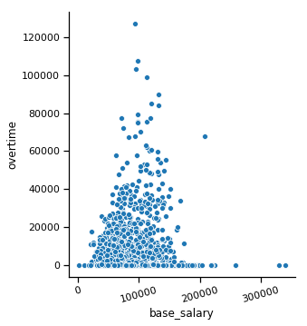

```python
# relplot `base_salary` vs `overtime`
sb.relplot(data = sf_subset, x = 'base_salary', y = 'overtime');
plt.xticks(rotation = 15);
```

```python
sf_subset[{'base_salary', 'overtime', 'log_salary',
             'cr_overtime'}].corr()
```

|  | cr_overtime | overtime | log_salary | base_salary |
| --- | --- | --- | --- | --- |
| cr_overtime | 1.00 | 0.83 | 0.04 | 0.00 |
| overtime | 0.83 | 1.00 | 0.14 | 0.11 |
| log_salary | 0.04 | 0.14 | 1.00 | 0.94 |
| base_salary | 0.00 | 0.11 | 0.94 | 1.00 |

> Found only a tiny correlation between `salary` and `overtime`. I thought it would be higher because overtime is dependent on salary. Maybe, transforming the data might highlight more correlation.

##### `other_salary` vs `other_benefit`

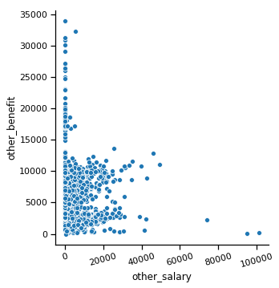

```python
# relplot `other_salary` vs `other_benefit`
sb.relplot(data = sf_subset, x = 'other_salary', y = 'other_benefit');
plt.xticks(rotation = 15);
```

```python
sf_subset[{'other_salary', 'other_benefit', 'cr_other_salary',
             'cr_other_benefit'}].corr()
```

|  | other_salary | cr_other_salary | other_benefit | cr_other_benefit |
| --- | --- | --- | --- | --- |
| other_salary | 1.00 | 0.80 | -0.12 | -0.17 |
| cr_other_salary | 0.80 | 1.00 | -0.20 | -0.23 |
| other_benefit | -0.12 | -0.20 | 1.00 | 0.94 |
| cr_other_benefit | -0.17 | -0.23 | 0.94 | 1.00 |

> Same approach as `overtime` and `other_benefit` but no conclusions have been made thus far.

#### `org_group` vs `total_comp`

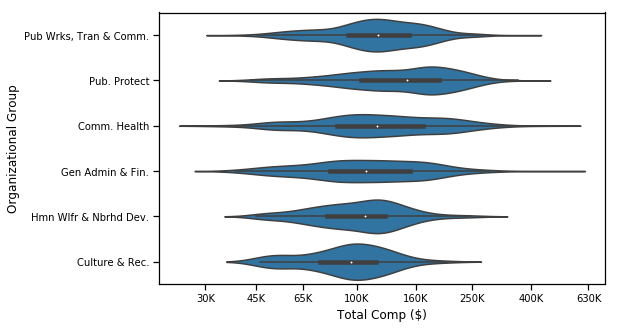

```python
fig, ax = plt.subplots(figsize = [8, 5])
x_ticks = log_trans(np.array([30000, 45000, 65000, 100000, 160000, 250000, 400000, 630000]))
sb.violinplot(data = sf_subset, y = 'org_group',
              x = 'log_total_comp', color = base_color)
ax.tick_params(axis = 'both', which = 'major',labelsize = 10);
plt.xlabel('Total Comp ($)')
plt.ylabel('Organizational Group');
plt.xticks(x_ticks, ['30K', '45K', '65K', '100K',
                     '160K', '250K', '400K', '630K' ]);
```

> Public Protection has the highest median total compensation indicating the best overall pay for those employees in those departments. Culture and Recreation has the smallest range and highest concentration around the median indicating a lower variability of salary and benefits. Community Health had the least concentrated distribution which indicates a high variability for salary and benefits. It would be interesting to see the percentage distributions of the variables making up total benefits and total salaries.

#### `job` vs `total_comp`

```python
# to get job subset
job_subset = (sf_subset[sf_subset.job.isin(top_five_job)])
```

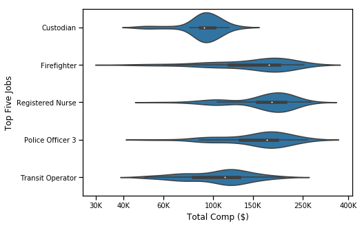

```python
# BY JOB BY TOTAL_COMP
fig, ax = plt.subplots(figsize = [7, 5])
sb.violinplot(data = job_subset, y = 'job', x = 'log_total_comp', color = base_color)
ax.tick_params(axis = 'both', which = 'major',labelsize = 10)
plt.xticks(log_trans(np.array([30000, 40000, 60000, 100000, 150000, 250000, 400000])),
          ['30K', '40K', '60K', '100K', '150K', '250K', '400K'])
plt.xlabel('Total Comp ($)')
plt.ylabel('Top Five Jobs');
```

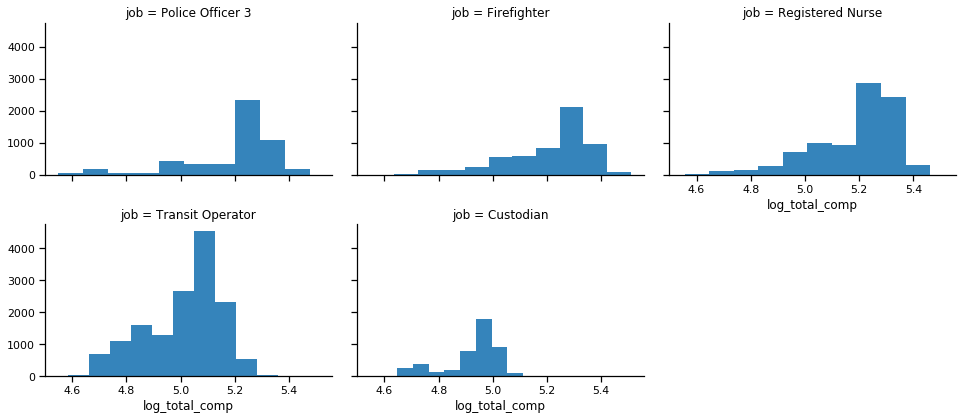

```python
job_sub = sf_data_trans[sf_data_trans['job'].isin(top_five_job)]
g = sb.FacetGrid(job_sub, col = 'job', height = 3, aspect = 1.5,
                 col_wrap = 3, legend_out = True)
g.map(plt.hist, 'log_total_comp', alpha = 0.9);
g.add_legend();
```

> Custodian has the smallest distribution of total compensation and the lowest median. This follows conventions that a lower-skilled worker would be paid the least and have less room for advancement or flexibility in salary or benefits. Registered Nurse has the highest median total compensation and a wider range of the distribution of total compensation. This is understandable because Nurses are highly skilled and highly educated workers. It would be interesting to see the distribution of their pay.

### Talk about some of the relationships you observed in this part of the investigation. How did the feature(s) of interest vary with other features in the dataset?

> The heatmap showed positive strong correlations between `total_comp` and the other numerical features. This is logical considering `total_comp` is a collective product of the other varaiables combined. When compared with the `org_group` it was surprising that Public Protection had the highest median pay, considering in most places, compensation for firefighters, policemen, etc are poorly paid. When compared with the top five jobs, it followed the typical conventions of highly skilled workers are paid better.

### Did you observe any interesting relationships between the other features (not the main feature(s) of interest)?

> The relationship between `other_benefit` compared to `other_salary` and `overtime` had a negative correlation. This seemed counterintuitive because `other_benefit` are the benefits paid on behalf of the employer towards medicare, social security, unemployment insurance, etc. Therefore, an increase in pay should result in an increase in benefits paid because it is based on percentage of income.

## Multivariate Exploration

> Create plots of three or more variables to investigate your data even further. Make sure that your investigations are justified, and follow from your work in the previous sections.

#### `org_group` vs `base_salary`, `overtime`, `other_salary`

```python
# salary variables
mean_org_sal = sf_data.groupby('org_group')[['base_salary', 'overtime', 'other_salary']].agg('mean')
mean_org_sal
```

| org_group | base_salary | overtime | other_salary |
| --- | --- | --- | --- |
| Pub Wrks, Tran & Comm. | 74329.96 | 6729.84 | 2930.71 |
| Pub. Protect | 93675.83 | 13706.03 | 8527.30 |
| Comm. Health | 80072.94 | 2617.64 | 4852.53 |
| Gen Admin & Fin. | 84508.98 | 1157.14 | 1393.51 |
| Hmn Wlfr & Nbrhd Dev. | 71271.79 | 1170.66 | 879.92 |
| Culture & Rec. | 64524.48 | 2158.90 | 1470.03 |

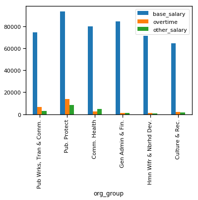

```python
mean_org_sal.plot(kind='bar');
```

```python
# found percentage to see proportions
salary_percents = mean_org_sal.div(mean_org_sal.sum(1), axis = 0)
salary_percents
```

| org_group | base_salary | overtime | other_salary |
| --- | --- | --- | --- |
| Pub Wrks, Tran & Comm. | 0.88 | 0.08 | 0.03 |
| Pub. Protect | 0.81 | 0.12 | 0.07 |
| Comm. Health | 0.91 | 0.03 | 0.06 |
| Gen Admin & Fin. | 0.97 | 0.01 | 0.02 |
| Hmn Wlfr & Nbrhd Dev. | 0.97 | 0.02 | 0.01 |
| Culture & Rec. | 0.95 | 0.03 | 0.02 |

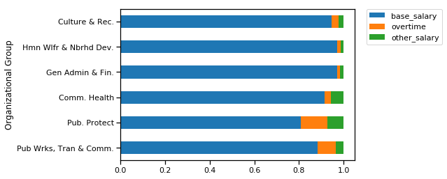

```python
# charted proportions
salary_percents.plot(kind = 'barh', stacked = True);
plt.legend(bbox_to_anchor=(1.05, 1), loc = 'upper left', borderaxespad = 0.);
plt.ylabel('Organizational Group');
```

#### `org_group` vs. `retirement`, `health_dental`, `other_benefits`

```python
# benefits Variables
mean_org_bene = sf_data.groupby('org_group')[['retirement',
                                              'health_dental',
                                              'other_benefit']].agg('mean')
# found percentage to see proportions
benefit_percents = mean_org_bene.div(mean_org_bene.sum(1), axis = 0)
benefit_percents
```

| org_group | retirement | health_dental | other_benefit |
| --- | --- | --- | --- |
| Pub Wrks, Tran & Comm. | 0.43 | 0.37 | 0.19 |
| Pub. Protect | 0.53 | 0.37 | 0.10 |
| Comm. Health | 0.45 | 0.36 | 0.19 |
| Gen Admin & Fin. | 0.45 | 0.35 | 0.20 |
| Hmn Wlfr & Nbrhd Dev. | 0.42 | 0.40 | 0.18 |
| Culture & Rec. | 0.41 | 0.41 | 0.18 |

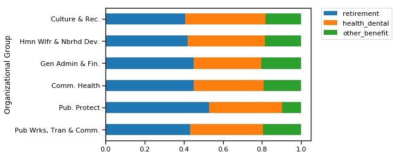

```python
# charted proportions
benefit_percents.plot(kind = 'barh', stacked = True);
plt.legend(bbox_to_anchor=(1.05, 1), loc = 'upper left', borderaxespad = 0.);
plt.ylabel('Organizational Group');
```

> Public Protection again had the lowest contribution to `other_benefit`, which is odd because they had the highest median `total_comp` earlier. Investigating further the break down of all variables for Pub Protection would highlight some things.

##### `org_group` vs `all`

```python
# ALL Variables
mean_org_total = sf_data.groupby('org_group')[['base_salary',
                                              'overtime',
                                              'other_salary',
                                              'retirement',
                                              'health_dental',
                                              'other_benefit']].agg('mean')
# found percentage to see proportions
total_percents = mean_org_total.div(mean_org_total.sum(1), axis = 0)
total_percents
```

| org_group | base_salary | overtime | other_salary | retirement | health_dental | other_benefit |
| --- | --- | --- | --- | --- | --- | --- |
| Pub Wrks, Tran & Comm. | 0.62 | 0.06 | 0.02 | 0.13 | 0.11 | 0.06 |
| Pub. Protect | 0.61 | 0.09 | 0.06 | 0.13 | 0.09 | 0.02 |
| Comm. Health | 0.66 | 0.02 | 0.04 | 0.12 | 0.10 | 0.05 |
| Gen Admin & Fin. | 0.68 | 0.01 | 0.01 | 0.13 | 0.10 | 0.06 |
| Hmn Wlfr & Nbrhd Dev. | 0.67 | 0.01 | 0.01 | 0.13 | 0.12 | 0.06 |
| Culture & Rec. | 0.65 | 0.02 | 0.01 | 0.13 | 0.13 | 0.06 |

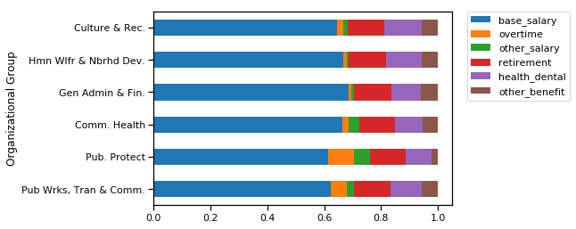

```python
# charted proportions
total_percents.plot(kind = 'barh', stacked = True);
plt.legend(bbox_to_anchor=(1.05, 1), loc = 'upper left', borderaxespad = 0.);
plt.ylabel('Organizational Group');
```

> - Public Protection had the lowest `base_salary` as part of total_compensation at 61%, with Gen Admin & Fin having the highest at 68%.
> - Public Protection had the lowest contribution to `other_benefit` and the highest for `overtime` and `other_salary`.

##### Top Five Jobs vs. Salary, Overtime, Other Salary

```python
# salary variables
job_sub = sf_data_trans[sf_data_trans['job'].isin(top_five_job)]
mean_job_sal = job_sub.groupby('job')[['base_salary',
                                       'overtime',
                                       'other_salary']].agg('mean')
# found percentage to see proportions
sal_percent_job = mean_job_sal.div(mean_job_sal.sum(1), axis = 0)
sal_percent_job
```

| job | base_salary | overtime | other_salary |
| --- | --- | --- | --- |
| Custodian | 0.91 | 0.03 | 0.06 |
| Firefighter | 0.72 | 0.17 | 0.11 |
| Police Officer 3 | 0.79 | 0.14 | 0.07 |
| Registered Nurse | 0.88 | 0.02 | 0.10 |
| Transit Operator | 0.79 | 0.17 | 0.04 |

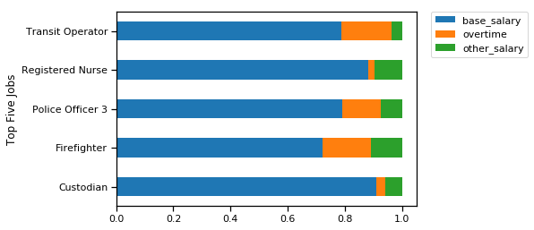

```python
# charted proportions
sal_percent_job.plot(kind = 'barh', stacked = True);
plt.legend(bbox_to_anchor=(1.05, 1), loc = 'upper left', borderaxespad = 0.);
plt.ylabel('Top Five Jobs');
```

> The majority of total salary starts with the `base_salary` which is to be expected. Transit Operator, Firefighter, and Police Officer 3 have the most variability because they have a higher percentage of total salary in `overtime` and `other_salary`. These tend to fluctuate based on a number of factors such as hours worked, type of shift, etc. The Custodian has the most stability because their `base_salary` makes up the majority of their salary.

##### Top Jobs vs Retirement, Health/Dental, Other_Benefits

```python
# salary variables
mean_job_bene = job_sub.groupby('job')[['retirement',
                                        'health_dental',
                                        'other_benefit']].agg('mean')
# found percentage to see proportions
bene_percent_job = mean_job_bene.div(mean_job_bene.sum(1), axis = 0)
bene_percent_job
```

| job | retirement | health_dental | other_benefit |
| --- | --- | --- | --- |
| Custodian | 0.37 | 0.48 | 0.15 |
| Firefighter | 0.51 | 0.43 | 0.06 |
| Police Officer 3 | 0.56 | 0.38 | 0.06 |
| Registered Nurse | 0.52 | 0.29 | 0.18 |
| Transit Operator | 0.42 | 0.42 | 0.17 |

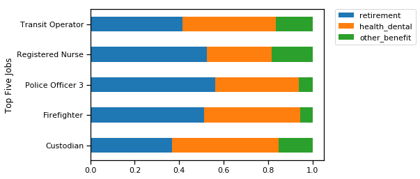

```python
# charted proportions
bene_percent_job.plot(kind = 'barh', stacked = True);
plt.legend(bbox_to_anchor=(1.05, 1), loc = 'upper left', borderaxespad = 0.);
plt.ylabel('Top Five Jobs');
```

> This shows that Registered Nurses, Firefighters, and Police Officers 3 have more contributions to retirement proportionally than Transit Operator and Custodian. This is probably because they have more disposible income to put more towards retirement than the others. Also note that Police Officer 3 and Firefighter have the lowest contribution to `other_benefit` because some can "opt" out of those certain taxes. This might skew the results of the others in comparison.

```python
# ALL variables
mean_job_total = job_sub.groupby('job')[['base_salary',
                                         'overtime',
                                         'other_salary',
                                         'retirement',
                                         'health_dental',
                                         'other_benefit']].agg('mean')
# found percentage to see proportions
sal_percent_total = mean_job_total.div(mean_job_total.sum(1), axis = 0)
sal_percent_total
```

| job | base_salary | overtime | other_salary | retirement | health_dental | other_benefit |
| --- | --- | --- | --- | --- | --- | --- |
| Custodian | 0.60 | 0.02 | 0.04 | 0.13 | 0.16 | 0.05 |
| Firefighter | 0.56 | 0.13 | 0.08 | 0.12 | 0.10 | 0.01 |
| Police Officer 3 | 0.63 | 0.11 | 0.06 | 0.12 | 0.08 | 0.01 |
| Registered Nurse | 0.66 | 0.02 | 0.07 | 0.13 | 0.07 | 0.05 |
| Transit Operator | 0.54 | 0.12 | 0.03 | 0.13 | 0.13 | 0.05 |

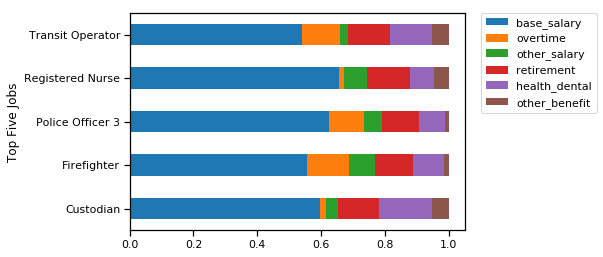

```python
# charted proportions
sal_percent_total.plot(kind = 'barh', stacked = True);
plt.legend(bbox_to_anchor=(1.05, 1), loc = 'upper left', borderaxespad = 0.);
plt.ylabel('Top Five Jobs');
```

> This overview of all parts of the breakdown of total compensation can help highlight the biggest contributors.

#### Plot by `job` , `total_salary` vs `total_benefit`

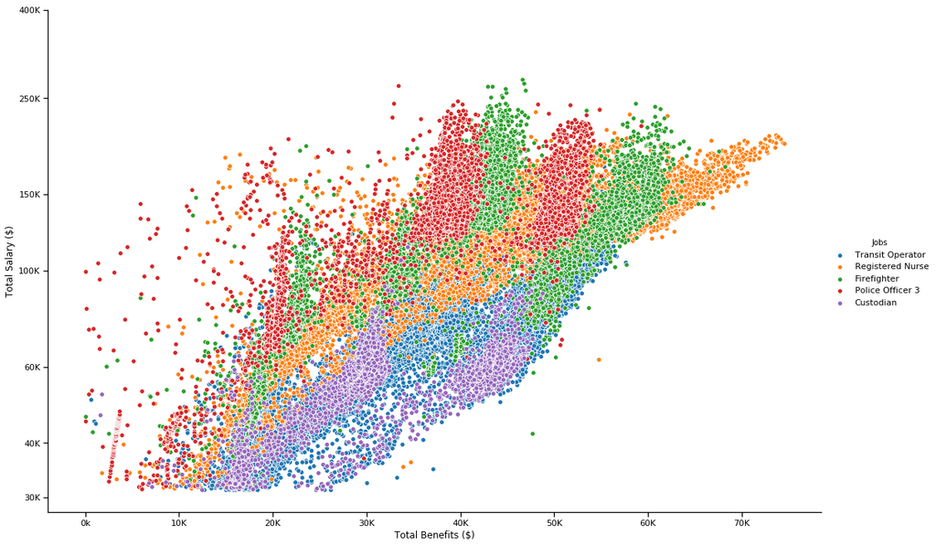

```python
g = sb.FacetGrid(data = job_sub, hue = 'job', hue_order = top_five_job,
                height = 10, aspect = 1.5)
g.map(sb.scatterplot, 'total_benefit',
      'log_total_salary').set(yticks=log_trans(np.array([30000, 40000, 60000,
                                                         100000, 150000,
                                                         250000, 400000])));
g.add_legend(title='Jobs');
g.set_ylabels('Total Salary ($)');
g.set_yticklabels(['30K', '40K', '60K', '100K', '150K', '250K', '400K'])
g.set_xticklabels([0, '0k', '10K', '20K', '30K', '40K', '50K', '60K', '70K'])
g.set_xlabels('Total Benefits ($)');
```

```python
g = sb.FacetGrid(data = job_sub, hue = 'job', hue_order = top_five_job,
                height = 10, aspect = 1.5)
g.map(sb.scatterplot, 'total_benefit',
      'log_total_salary').set(yticks=[4.6, 4.8, 5.0, 5.2, 5.4]);
yticks=log_trans(np.array([30000, 40000, 60000, 100000, 150000, 250000, 400000])),
g.add_legend();
g.set_ylabels('Total Salary ($)');
g.set_yticklabels(['50K'])
```

[output not shown]

> The scattor plot of `log_total_salary` v `total_benefit` shows a positive linear trend. There is a hue of job code of the top 5 jobs to see which ones are more correlated. Police Officer 3 is the least linear while Registered Nurse is the most linear. Firefighter looks the same as Police Officer 3. This might have something to do with the `other_benefits` having the option to opt out. A faceted grid might have a better view.

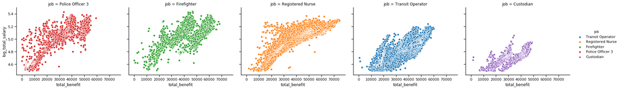

```python
g = sb.FacetGrid(data = job_sub, col = 'job',
                 hue = 'job', height = 4, aspect = 1.25, hue_order = top_five_job)
g.map(sb.scatterplot, 'total_benefit', 'log_total_salary');
g.add_legend();
```

> The faceted view gives a better visual of the differences between jobs.

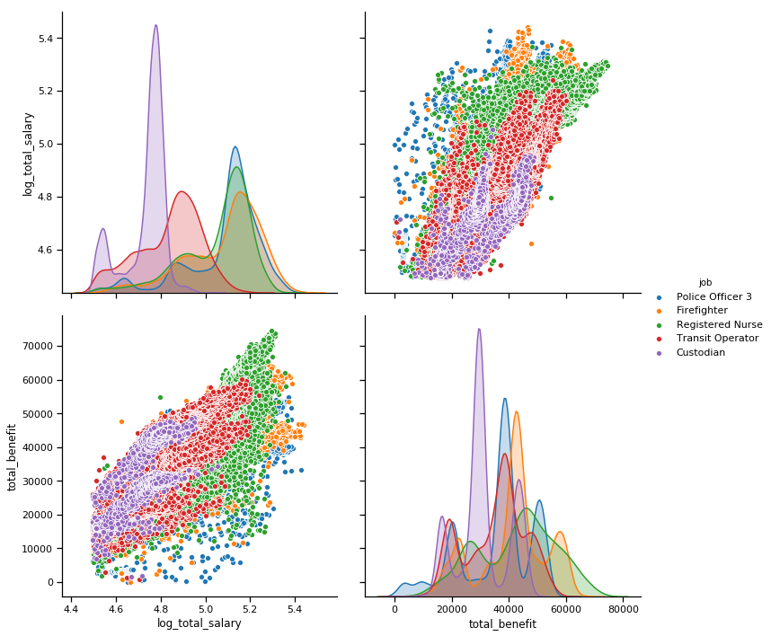

```python
sb.pairplot(job_sub, hue = 'job', vars = ['log_total_salary', 'total_benefit'],
           height = 5);
```

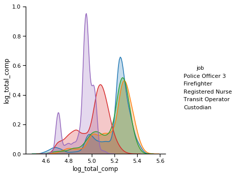

```python
sb.pairplot(job_sub, hue = 'job', vars = ['log_total_comp'],
           height = 5);
```

> At the end of your report, make sure that you export the notebook as an html file from the `File > Download as... > HTML` menu. Make sure you keep track of where the exported file goes, so you can put it in the same folder as this notebook for project submission. Also, make sure you remove all of the quote-formatted guide notes like this one before you finish your report!